# R Notebook - Building Time Series Models for the Covid-19 dataset for India

**Loading the libraries**

```r
library(tseries)
library(forecast)
library(dplyr)

rm(list = ls())
```

**Loading the dataset**

```r
train_data <- read.csv("train.csv")
```

*Function to role up the dataset at Country level to get the cumulative cases*

```r
total_cases <- function(cname)
{
  country <- train_data[train_data$Country_Region == cname,]

  new_cases <- country %>% dplyr::select(Date, ConfirmedCases) %>%
                              group_by(Date) %>%
                                mutate(TotalConfirmedCases = sum(ConfirmedCases)) %>%
                                  ungroup()%>%
                                    dplyr::select(Date, TotalConfirmedCases) %>%
                                      distinct() %>%
                                        dplyr::select(TotalConfirmedCases) %>%
                                          filter(TotalConfirmedCases > 0)

  #Reading the TS file
  original_ts <- as.ts((new_cases$TotalConfirmedCases))
  return(original_ts)
}
```

*Function to plot the the time series, ACF and PACF - inout argument ts_object*

```r
plot_ts <- function(ts_object)
{
  par(mfrow=c(1,3))
  plot(ts_object)
  acf(ts_object)
  pacf(ts_object)

}
```

#### Data is selected for India

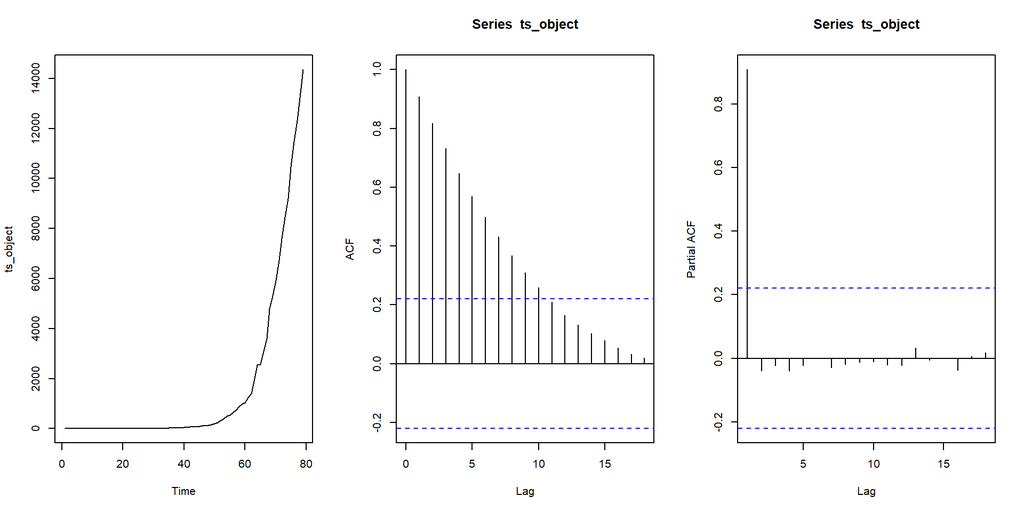

```r
india_cases_ts <- total_cases("India")
plot_ts(india_cases_ts)
```

From the time series plot we see that there is an upward increasing trend, and hence it is non-stationary (as expected). The ACF is decaying slowly and the PACF cuts off after lag 1. From the plots it is evident that the series is not stationary. However we will perform the ADF test to prove it statistically

Augmented Dickey-Fuller Test - Null hypothesis, H0: There is a unit root, i.e., homogeneous nonstationarity. - Alternative hypothesis, H1: There is no unit root, i.e., stationarity.

Therefore, a small p-value would indicates stationarity and large p-value indicates homogeneous nonstationarity, i.e., there is a unit root.

The test statistic has a special distribution that is not commonly seen, so it make more sense to just look at the p-value.

```r
adf.test(india_cases_ts)
```

```
##
##  Augmented Dickey-Fuller Test
##
## data:  india_cases_ts
## Dickey-Fuller = -0.15814, Lag order = 4, p-value = 0.99
## alternative hypothesis: stationary
```

Since p-value is large, we fail to reject the Null hypothesis. This implies non-stationarity. Some order differential might be appropriate for this series

Plotting the time series for a larger time series.

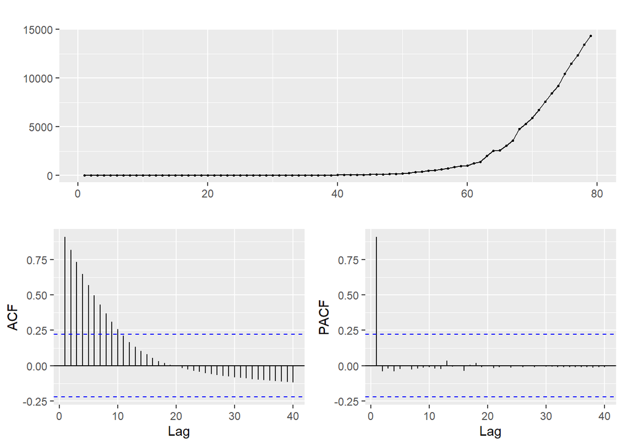

```r
india_cases_ts %>% ggtsdisplay(lag.max=40)
```

Creating a difference of the order 2 on the dataset and visualizing to glimpse at the plots

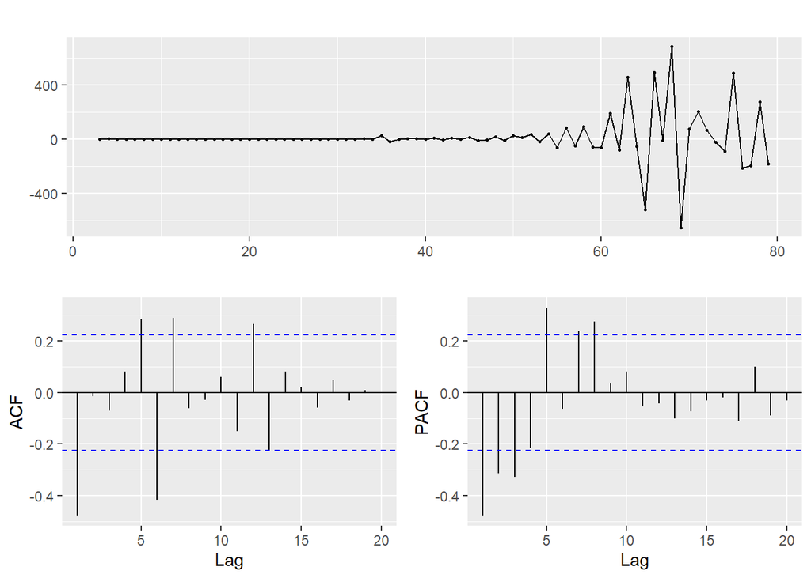

```r
india_cases_ts %>% diff() %>% diff() %>% ggtsdisplay(lag.max = 20)
```

Taking second order differencing in order to make the series stationary -

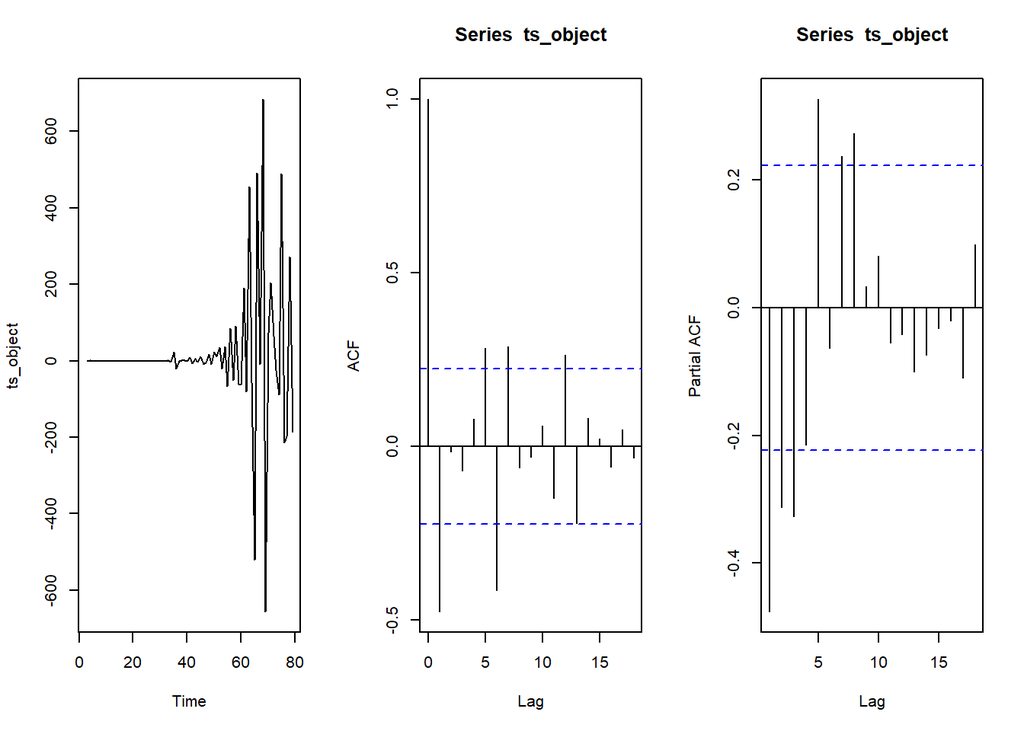

```r
india_cases_ts_diff <- india_cases_ts %>% diff(differences = 2)

plot_ts(india_cases_ts_diff)
```

```r
adf.test(india_cases_ts_diff)
```

```
##
##  Augmented Dickey-Fuller Test
##
## data:  india_cases_ts_diff
## Dickey-Fuller = -4.7132, Lag order = 4, p-value = 0.01
## alternative hypothesis: stationary
```

Running a few model variations with individual diagnostics for the same

Auto ARIMA

```r
auto_fit <- auto.arima(india_cases_ts)
auto_fit
```

```
## Series: india_cases_ts
## ARIMA(1,2,2)
##
## Coefficients:
##          ar1      ma1     ma2
##       0.7248  -1.6622  0.8629
## s.e.  0.1596   0.0992  0.0578
##
## sigma^2 estimated as 15647:  log likelihood=-480.7
## AIC=969.4   AICc=969.96   BIC=978.78
```

```r
Box.test(auto_fit$residuals, lag = 10, fitdf = 3)
```

```
##
##  Box-Pierce test
##
## data:  auto_fit$residuals
## X-squared = 13.917, df = 7, p-value = 0.05267
```

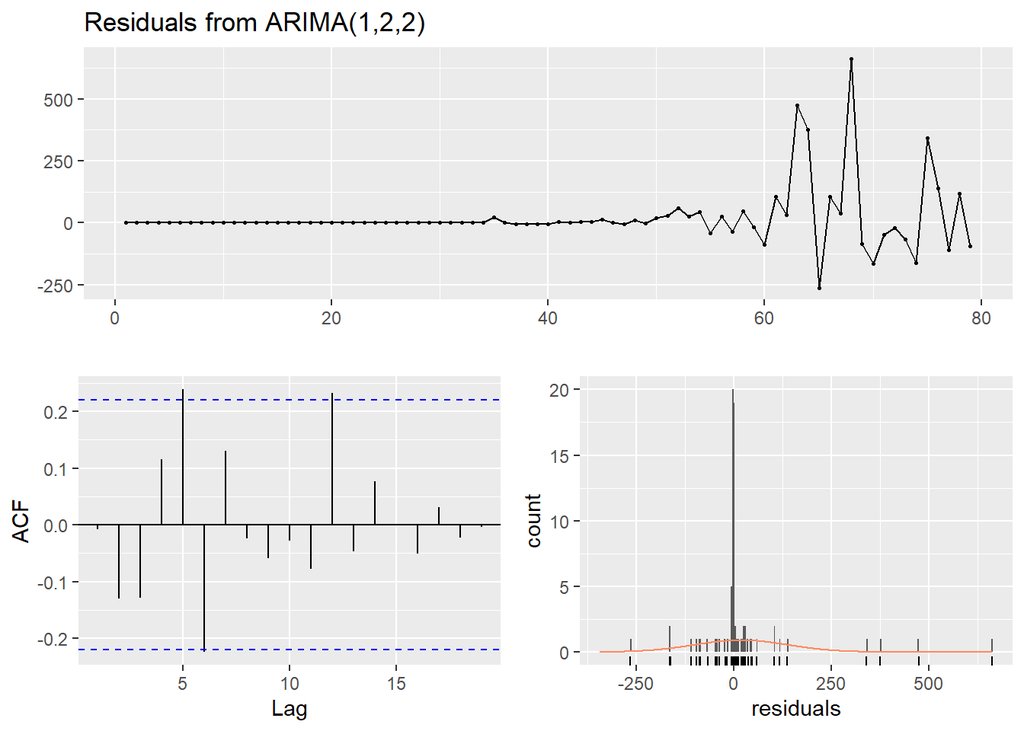

```
##
##  Ljung-Box test
##
## data:  Residuals from ARIMA(1,2,2)
## Q* = 15.248, df = 7, p-value = 0.03295
##
## Model df: 3.   Total lags used: 10
```

```r
checkresiduals(auto_fit)
```

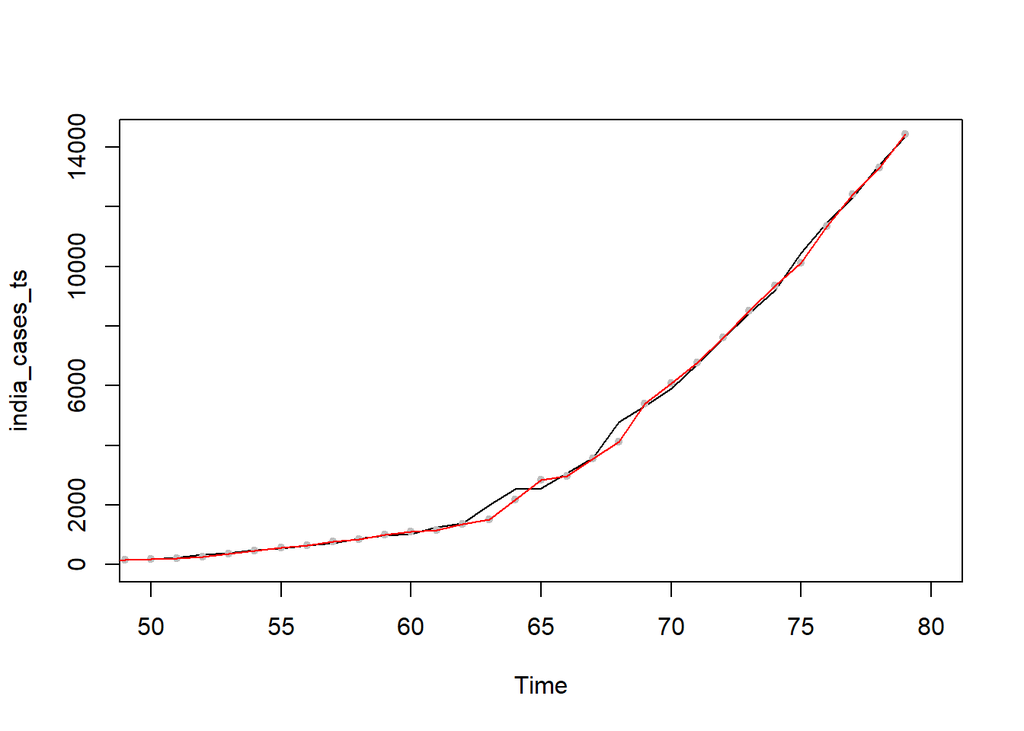

```r
par(mfrow=c(1,1))
plot(india_cases_ts, xlim = c(50,80))
points(fitted(auto_fit), pch = 20, col = "grey")
points(fitted(auto_fit), type = "l", col = "red")
```

ARIMA(2,2,2)

```r
fit1 <- arima(india_cases_ts, order = c(2,2,2))
fit1
```

```
##
## Call:
## arima(x = india_cases_ts, order = c(2, 2, 2))
##
## Coefficients:
##          ar1      ar2      ma1     ma2
##       0.5958  -0.3279  -1.5697  1.0000
## s.e.  0.1112   0.1165   0.0666  0.0759
##
## sigma^2 estimated as 13335:  log likelihood = -478.34,  aic = 966.69
```

```r
Box.test(fit1$residuals, lag = 10, fitdf = 4)
```

```
##
##  Box-Pierce test
##
## data:  fit1$residuals
## X-squared = 15.759, df = 6, p-value = 0.01511
```

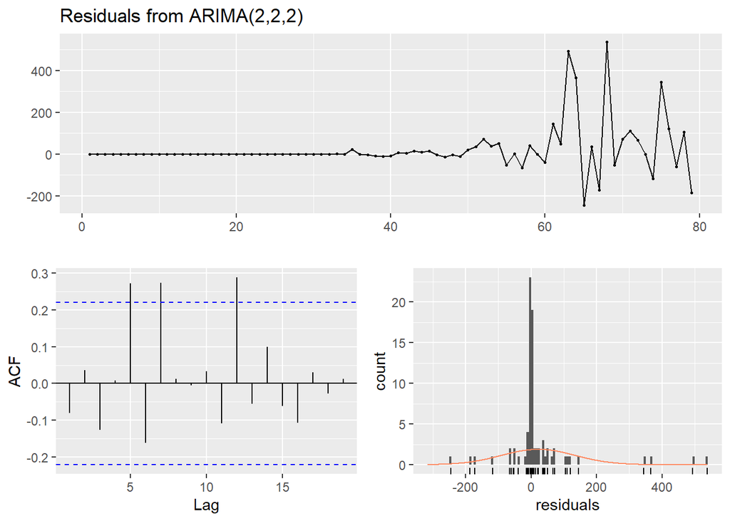

```
##
##  Ljung-Box test
##
## data:  Residuals from ARIMA(2,2,2)
## Q* = 17.398, df = 6, p-value = 0.007928
##
## Model df: 4.   Total lags used: 10
```

```r
checkresiduals(fit1)
```

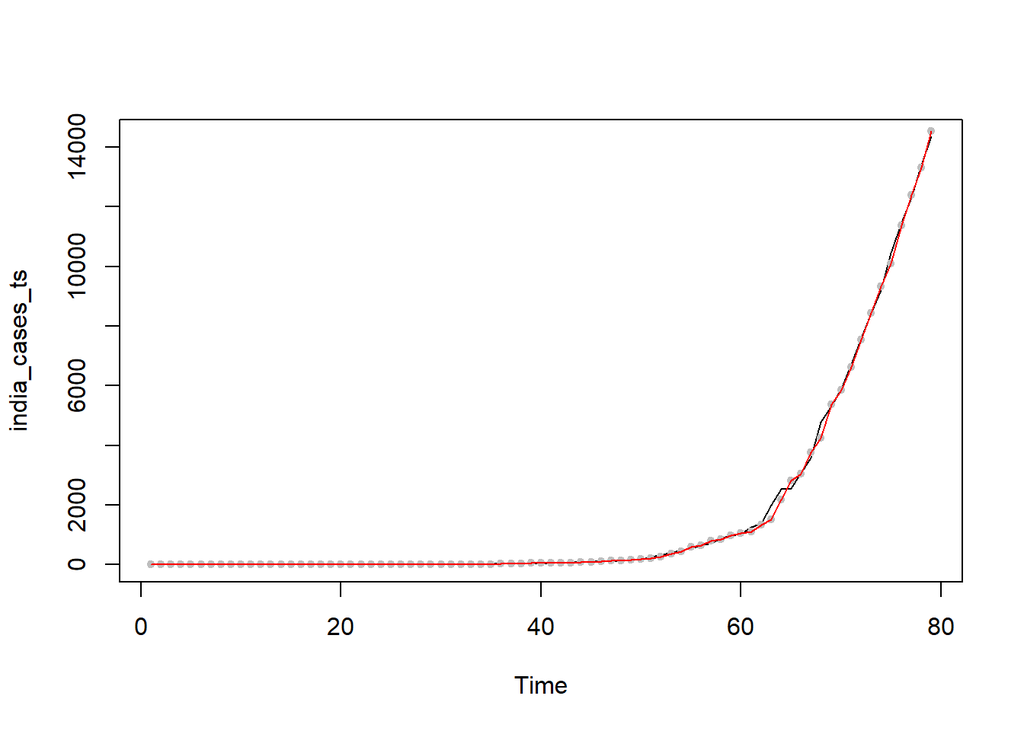

```r
par(mfrow=c(1,1))
plot(india_cases_ts)
points(fitted(fit1), pch = 20, col = "grey")
points(fitted(fit1), type = "l", col = "red")
```

ARIMA(0,2,4)

```r
fit2 <- arima(india_cases_ts, order = c(0,2,4))
fit2
```

```
##
## Call:
## arima(x = india_cases_ts, order = c(0, 2, 4))
##
## Coefficients:
##           ma1     ma2      ma3     ma4
##       -0.8083  0.3156  -0.2058  0.6277
## s.e.   0.2579  0.1616   0.2486  0.2544
##
## sigma^2 estimated as 13177:  log likelihood = -477.83,  aic = 965.66
```

```r
Box.test(fit2$residuals, lag = 10, fitdf = 4)
```

```
##
##  Box-Pierce test
##
## data:  fit2$residuals
## X-squared = 16.103, df = 6, p-value = 0.01321
```

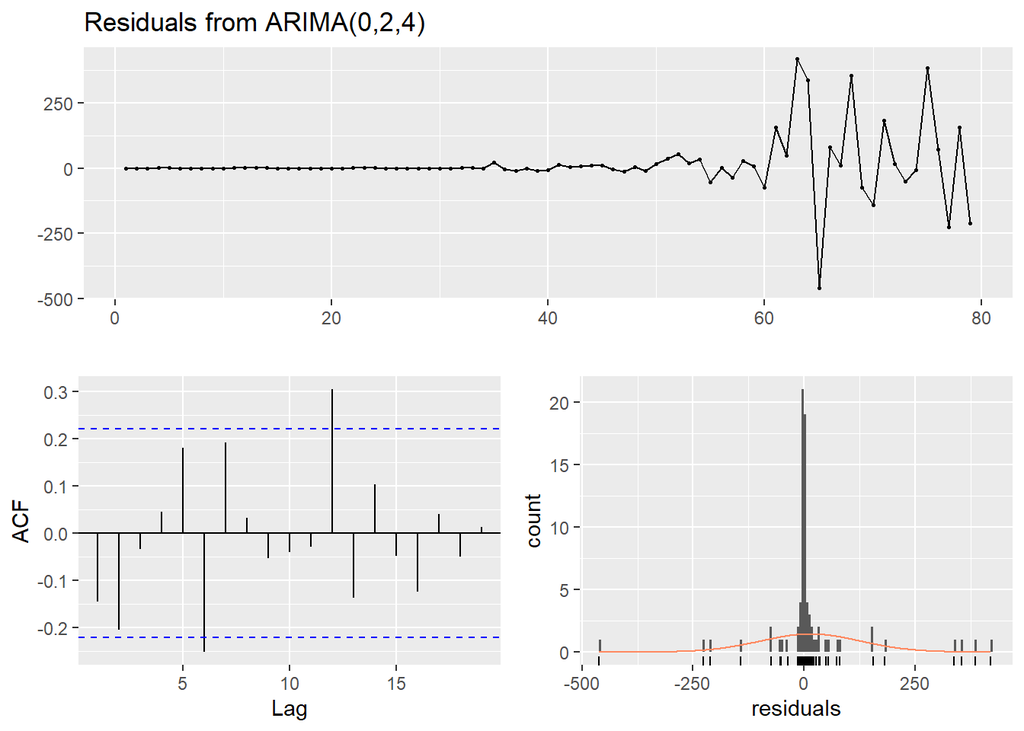

```
##
##  Ljung-Box test
##
## data:  Residuals from ARIMA(0,2,4)
## Q* = 17.58, df = 6, p-value = 0.007371
##
## Model df: 4.   Total lags used: 10
```

```r
checkresiduals(fit2)
```

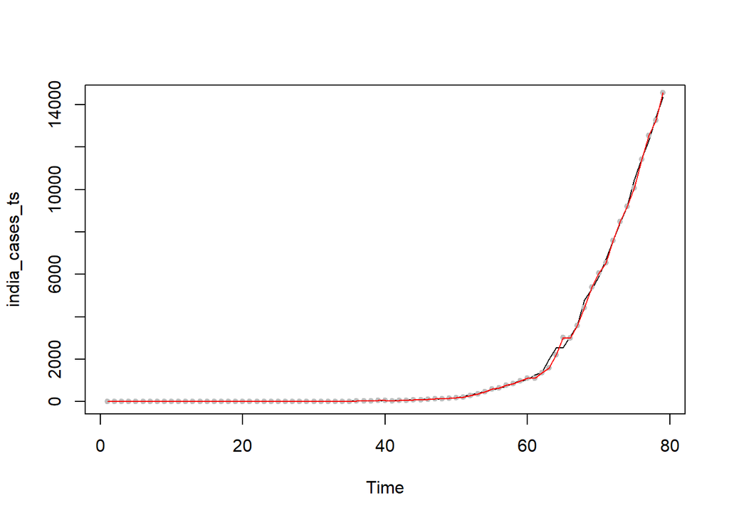

```r
par(mfrow=c(1,1))
plot(india_cases_ts)
points(fitted(fit2), pch = 20, col = "grey")
points(fitted(fit2), type = "l", col = "red")
```

ARIMA(1,2,0)

```r
fit3 <- arima(india_cases_ts, order = c(1,2,0))
fit3
```

```
##
## Call:
## arima(x = india_cases_ts, order = c(1, 2, 0))
##
## Coefficients:
##           ar1
##       -0.4693
## s.e.   0.1003
##
## sigma^2 estimated as 22148:  log likelihood = -494.59,  aic = 993.19
```

```r
Box.test(fit3$residuals, lag = 10, fitdf = 1)
```

```
##
##  Box-Pierce test
##
## data:  fit3$residuals
## X-squared = 33.608, df = 9, p-value = 0.0001046
```

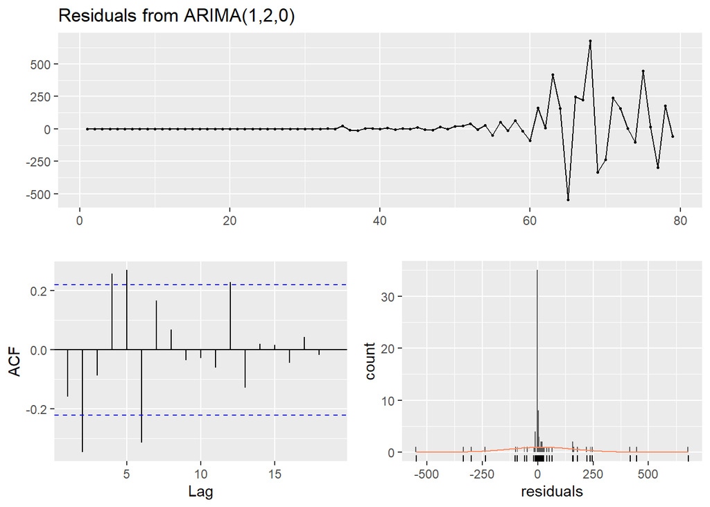

```
##
##  Ljung-Box test
##
## data:  Residuals from ARIMA(1,2,0)
## Q* = 36.389, df = 9, p-value = 3.381e-05
##
## Model df: 1.   Total lags used: 10
```

```r
checkresiduals(fit3)
```

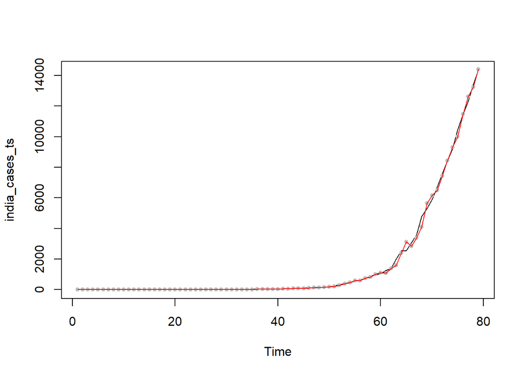

```r
par(mfrow=c(1,1))
plot(india_cases_ts)
points(fitted(fit3), pch = 20, col = "grey")
points(fitted(fit3), type = "l", col = "red")
```

ARIMA(2,2,4)

```r
fit4 <- arima(india_cases_ts, order = c(2,2,4))
fit4
```

```
##
## Call:
## arima(x = india_cases_ts, order = c(2, 2, 4))
##
## Coefficients:
##           ar1      ar2      ma1     ma2      ma3     ma4
##       -0.1476  -0.5100  -0.7743  0.7343  -0.7743  1.0000
## s.e.   0.1040   0.1107   0.1028  0.0873   0.1084  0.1362
##
## sigma^2 estimated as 10010:  log likelihood = -470.19,  aic = 954.38
```

```r
Box.test(fit4$residuals, lag = 10, fitdf = 6)
```

```
##
##  Box-Pierce test
##
## data:  fit4$residuals
## X-squared = 8.7344, df = 4, p-value = 0.06809
```

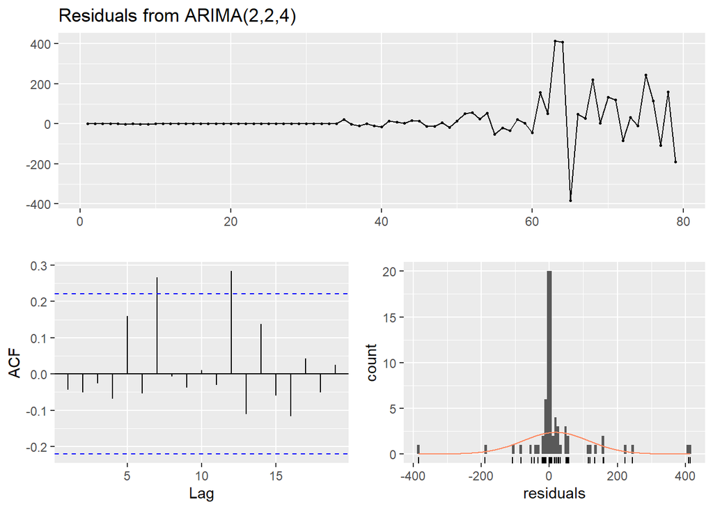

```
##
##  Ljung-Box test
##
## data:  Residuals from ARIMA(2,2,4)
## Q* = 9.7172, df = 4, p-value = 0.04547
##
## Model df: 6.   Total lags used: 10
```

```r
checkresiduals(fit4)
```

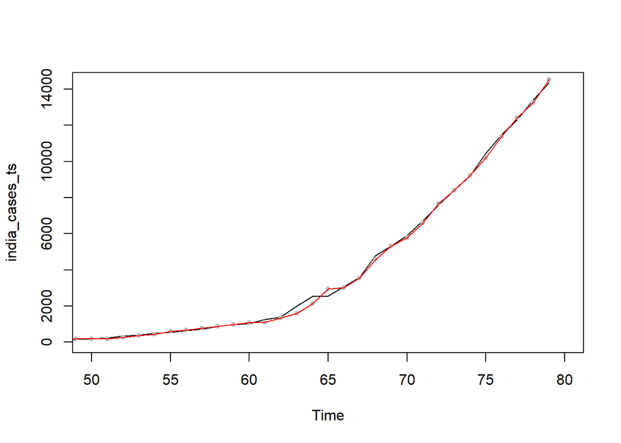

```r
par(mfrow=c(1,1))
plot(india_cases_ts, xlim = c(50,80))
points(fitted(fit4), pch = 20, col = "grey")
points(fitted(fit4), type = "l", col = "red")
```

ARIMA(4,2,4)

```r
fit5 <- arima(india_cases_ts, order = c(4,2,4))
fit5
```

```
##
## Call:
## arima(x = india_cases_ts, order = c(4, 2, 4))
##
## Coefficients:
##           ar1      ar2      ar3      ar4      ma1      ma2     ma3     ma4
##       -0.8184  -0.2631  -0.1189  -0.4632  -0.1170  -0.3235  0.0200  0.9119
## s.e.   0.1338   0.1638   0.1646   0.1278   0.1118   0.1462  0.1595  0.1141
##
## sigma^2 estimated as 11033:  log likelihood = -471.78,  aic = 961.56
```

```r
Box.test(fit5$residuals, lag = 10, fitdf = 8)
```

```
##
##  Box-Pierce test
##
## data:  fit5$residuals
## X-squared = 10.603, df = 2, p-value = 0.004985
```

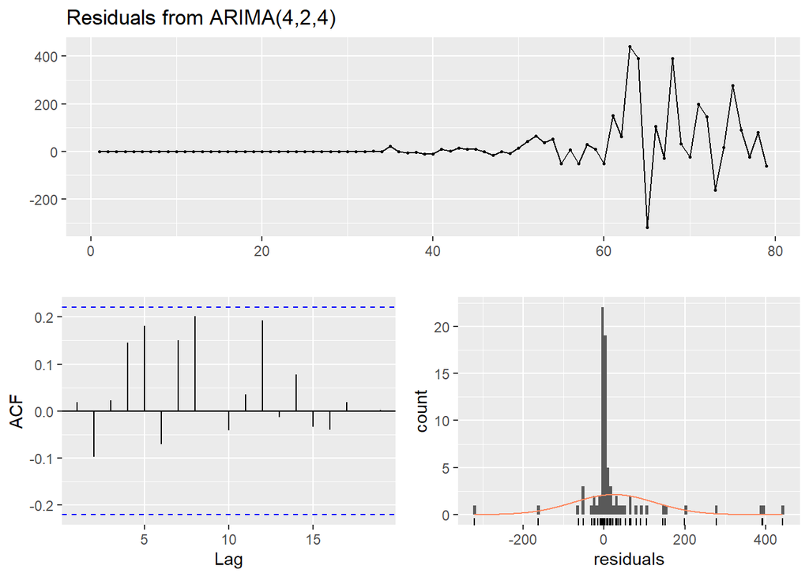

```
##
##  Ljung-Box test
##
## data:  Residuals from ARIMA(4,2,4)
## Q* = 11.887, df = 3, p-value = 0.007781
##
## Model df: 8.   Total lags used: 11
```

```r
checkresiduals(fit5)
```

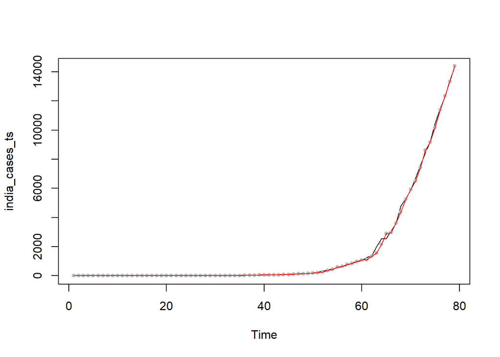

```r
par(mfrow=c(1,1))
plot(india_cases_ts)
points(fitted(fit5), pch = 20, col = "grey")
points(fitted(fit5), type = "l", col = "red")
```

Compare the models built by ARIMA(1,2,2) and ARIMA(2,2,4)

```r
#Variable importance of ARIMA(1,2,2)
(1-pnorm(abs(auto_fit$coef)/sqrt(diag(auto_fit$var.coef))))*2
```

```
##          ar1          ma1          ma2
## 5.591854e-06 0.000000e+00 0.000000e+00
```

```r
#Variable importane of ARIMA(2,2,4)
(1-pnorm(abs(fit4$coef)/sqrt(diag(fit4$var.coef))))*2
```

```
##          ar1          ar2          ma1          ma2          ma3          ma4
## 1.559583e-01 4.088411e-06 5.018208e-14 0.000000e+00 9.192647e-13 2.138290e-13
```

Forecast for both the models

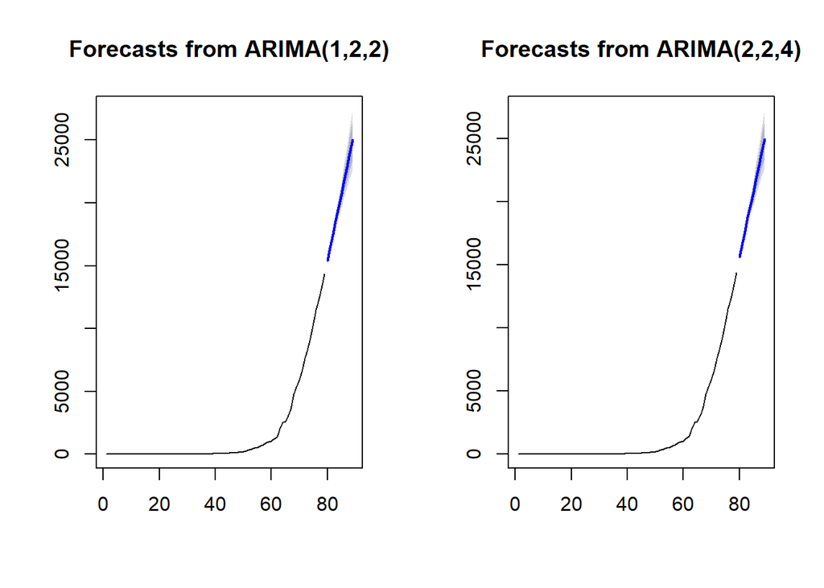

```r
par(mfrow = c(1,2))
plot(forecast(auto_fit, h = 10))
plot(forecast(fit4, h = 10))
```

```r
forecast(auto_fit, h = 10)
```

```
##    Point Forecast    Lo 80    Hi 80    Lo 95    Hi 95
## 80       15398.16 15237.85 15558.46 15152.99 15643.32
## 81       16452.53 16218.62 16686.45 16094.79 16810.27
## 82       17512.87 17198.65 17827.09 17032.31 17993.43
## 83       18577.52 18162.85 18992.20 17943.33 19211.71
## 84       19645.31 19104.70 20185.91 18818.52 20472.09
## 85       20715.36 20021.92 21408.79 19654.84 21775.88
## 86       21787.05 20914.36 22659.75 20452.38 23121.72
## 87       22859.94 21782.85 23937.04 21212.67 24507.22
## 88       23933.70 22628.58 25238.81 21937.70 25929.69
## 89       25008.07 23452.85 26563.30 22629.56 27386.59
```

```r
forecast(fit4, h = 10)
```

```
##    Point Forecast    Lo 80    Hi 80    Lo 95    Hi 95
## 80       15621.16 15489.78 15752.54 15420.24 15822.09
## 81       16568.45 16374.31 16762.60 16271.53 16865.38
## 82       17686.33 17408.15 17964.50 17260.90 18111.76
## 83       18758.84 18409.19 19108.49 18224.10 19293.58
## 84       19751.05 19267.95 20234.14 19012.22 20489.88
## 85       20778.24 20110.48 21446.01 19756.98 21799.50
## 86       21841.23 20987.29 22695.17 20535.24 23147.21
## 87       22881.09 21832.42 23929.75 21277.29 24484.88
## 88       23906.11 22637.96 25174.26 21966.64 25845.58
## 89       24945.11 23439.95 26450.27 22643.17 27247.06
```

Additional Code

Taking a log transform of the data

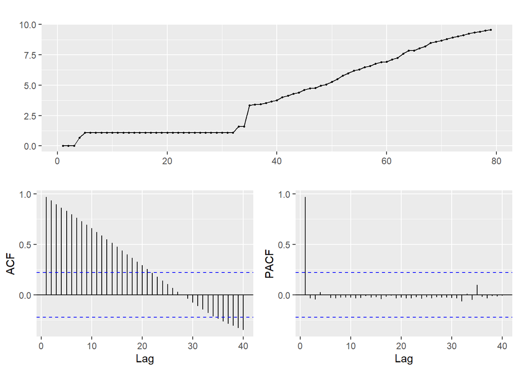

```r
india_cases_ts %>% log() %>% ggtsdisplay(lag.max=40)
```

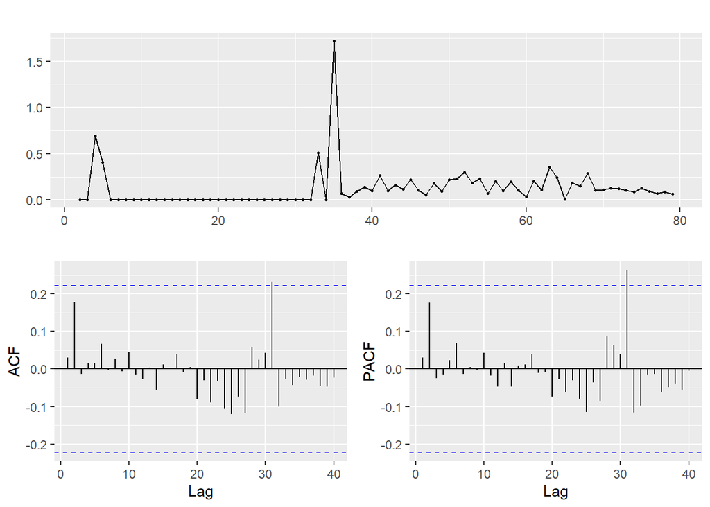

```r
india_cases_ts %>% log() %>% diff() %>% ggtsdisplay(lag.max=40)
```

```r
auto.arima(india_cases_ts %>% log())
```

```
## Series: india_cases_ts %>% log()
## ARIMA(0,1,0) with drift
##
## Coefficients:
##        drift
##       0.1227
## s.e.  0.0251
##
## sigma^2 estimated as 0.04989:  log likelihood=6.74
## AIC=-9.48   AICc=-9.32   BIC=-4.77
```

```r
total_cases_new <- function(cname)
{
  country <- train_data[train_data$Country_Region == cname,]

  new_cases <- country %>% dplyr::select(Date, ConfirmedCases) %>%
                              group_by(Date) %>%
                                mutate(TotalConfirmedCases = sum(ConfirmedCases)) %>%
                                  ungroup()%>%
                                    dplyr::select(Date, TotalConfirmedCases) %>%
                                      distinct() %>%
                                          filter(TotalConfirmedCases > 0)

  #Reading the TS file
  return(new_cases)
}
```